# Disaster Relief Project: Part I

Chelsea Alvarado

3/1/2021

**SYS 6018 | Spring 2021 | University of Virginia**

# Introduction

This project is aimed at being able to identify the location of displaced Haitian’s after the catastrophic 2010 earthquake using a characteristic blue tarp. The motivation behind this project is to be able to quickly identify locations so that rescue workers can provide needed assistance such as food and medicine. The data set being used consists of three predictor variables/features that represent RGB values and a response variable which is a Class representing what each observation represents based on the combination of RGB values. In its original form the data is multiclass. This project will train data on five different models including Logisitic Regression, Linear Discriminant Analysis, Quadratic Discriminant Analysis, K-Nearest Neighbors, and Penalized Logistic Regression. The Penalized Logistic Regression Model will be chosen by comparing Ridge, Lassso, and Elastic Net Regression and picking the model with the best accuracy as the final penalized logistic regression model. The data will be split into a 70/30 training/test split and predictors will be normalized.The models will train on a training set while also using 10-fold Cross-Validation and then test on test data for accuracy and predictive ability. Our models will be classifying our data as “Blue Tarp”,“Various Non-Tarp”, “Soil”, “Vegetation”, and “Rooftop” or in the case of logistic regression “Blue Tarp” or “Not Blue Trap”. Tuning parameters(k, lambda) will be selected using cross validation. The results of each model will be presented at the end of the report in a table.

# Training Data / EDA

## Exploratory Data Analysis

```r
#load in data
setwd("~/MSDS/Spring 2021/SYS6018/Project")
pix_data <- read.csv("HaitiPixels.csv")
pix_data <- as.data.frame(pix_data)
attach(pix_data)

#EDA
#quantitative
names(pix_data)
```

```
#> [1] "Class" "Red"   "Green" "Blue"
```

```r
head(pix_data)
```

```
#>        Class Red Green Blue
#> 1 Vegetation  64    67   50
#> 2 Vegetation  64    67   50
#> 3 Vegetation  64    66   49
#> 4 Vegetation  75    82   53
#> 5 Vegetation  74    82   54
#> 6 Vegetation  72    76   52
```

```r
summary(pix_data)
```

```
#>     Class                Red          Green            Blue
#>  Length:63241       Min.   : 48   Min.   : 48.0   Min.   : 44.0
#>  Class :character   1st Qu.: 80   1st Qu.: 78.0   1st Qu.: 63.0
#>  Mode  :character   Median :163   Median :148.0   Median :123.0
#>                     Mean   :163   Mean   :153.7   Mean   :125.1
#>                     3rd Qu.:255   3rd Qu.:226.0   3rd Qu.:181.0
#>                     Max.   :255   Max.   :255.0   Max.   :255.0
```

```r
dim(pix_data)
```

```
#> [1] 63241     4
```

```r
#check how many of each classification we have
sum(Class== "Vegetation")
```

```
#> [1] 26006
```

```r
sum(Class== "Blue Tarp")
```

```
#> [1] 2022
```

```r
sum(Class=="Rooftop")
```

```
#> [1] 9903
```

```r
sum(Class=="Soil")
```

```
#> [1] 20566
```

```r
sum(Class=="Various Non-Tarp")
```

```
#> [1] 4744
```

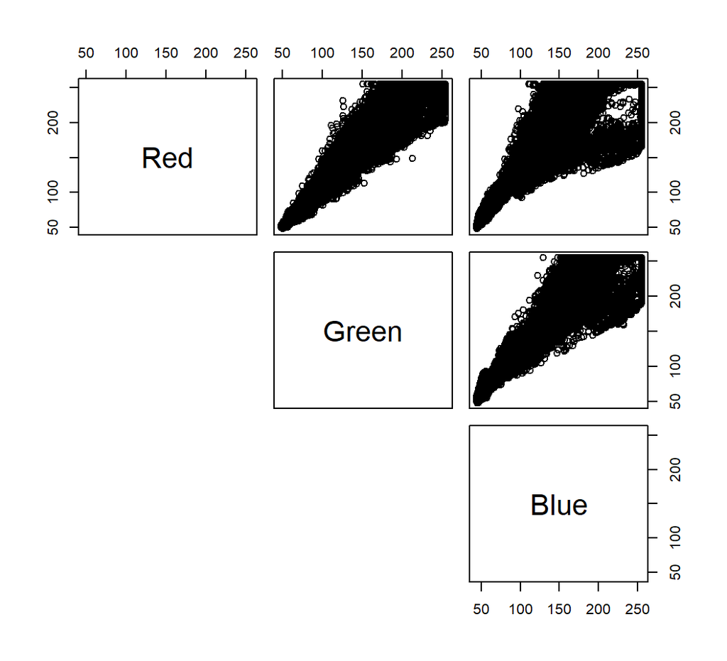

```r
#graphical
pairs(pix_data[,2:4], lower.panel = NULL)
```

```r
cor(pix_data[,2:4])
```

```
#>             Red     Green      Blue
#> Red   1.0000000 0.9815987 0.9355294
#> Green 0.9815987 1.0000000 0.9648024
#> Blue  0.9355294 0.9648024 1.0000000
```

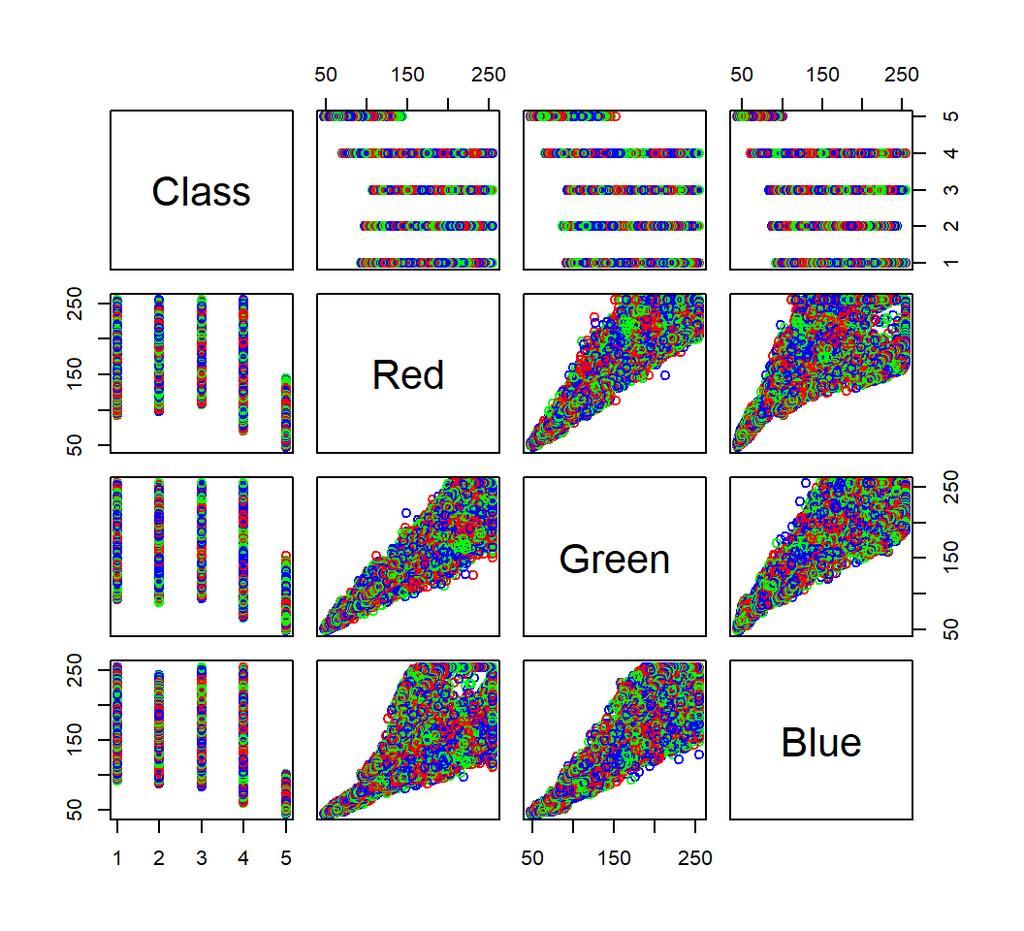

```r
plot(pix_data, col= c("red","green","blue")) # not very useful since a class would be determined by the combination of the three rgb values
```

```r
# Load Required Packages
library(tidyverse)
library(ISLR)
library(caret)
library(e1071)
library(boot)
library(pROC)
library(MASS)
library(class)
```

## Set-up and Train/Test Split

```r
#relabeling class names for classes that have spaces
pix_data$Class[pix_data$Class=="Blue Tarp"] <- "Blue.Tarp"
pix_data$Class[pix_data$Class=="Various Non-Tarp"] <- "Various.Non.Tarp"

#scramble data
set.seed(4444)
pix_data<-pix_data[sample(1:nrow(pix_data)),]


#normalize predictor values
normalize <-function(x) {
  (x- min(x))/(max(x)-min(x))
}

pix_datanorm <- as.data.frame(lapply(pix_data[c(2,3,4)], normalize))
pix_datanorm$Class<-pix_data[,1]
pix_data<-pix_datanorm

#factor class
pix_data$Class <- as.factor(pix_data$Class)
#data split 70/30
set.seed(32)
sample <- createDataPartition(pix_data$Class, p=0.7, list = FALSE)
train <- pix_data[sample,]
test <- pix_data[-sample,]

train.class <- pix_data$Class
test.class <- pix_data$Class
```

# Model Training

## Logistic Regression

```r
#https://www.youtube.com/watch?v=BQ1VAZ7jNYQ
#make new data frame but rename all variables that aren't blue tarp under one name
log_df<-pix_data

log_df$Class<- as.character(log_df$Class)

log_df$Class[log_df$Class=="Various.Non.Tarp"] <- "Non.Tarp"
log_df$Class[log_df$Class=="Soil"] <- "Non.Tarp"
log_df$Class[log_df$Class=="Vegetation"] <- "Non.Tarp"
log_df$Class[log_df$Class=="Rooftop"] <- "Non.Tarp"

#factor response and relevel
log_df$Class<-as.factor(log_df$Class)
log_df$Class <-relevel(log_df$Class, ref = "Non.Tarp")

#set up split
sample <- createDataPartition(log_df$Class, p=0.7, list = FALSE)
log.train <- log_df[sample,]
log.test <- log_df[-sample,]

#log.train.class <- log_df$Class
log.test.class <- log.test$Class

set.seed(4658)
specs <- trainControl(method = "cv", number = 10, classProbs=TRUE)

set.seed(356)

#model
log.mod <- train(log.train[,1:3],log.train[,4], method = "glm", family = "binomial", trControl = specs)

#model summary
log.mod
```

```
#> Generalized Linear Model
#>
#> 44270 samples
#>     3 predictor
#>     2 classes: 'Non.Tarp', 'Blue.Tarp'
#>
#> No pre-processing
#> Resampling: Cross-Validated (10 fold)
#> Summary of sample sizes: 39844, 39842, 39843, 39843, 39844, 39842, ...
#> Resampling results:
#>
#>   Accuracy   Kappa
#>   0.9950756  0.9169969
```

```r
summary(log.mod)
```

```
#>
#> Call:
#> NULL
#>
#> Deviance Residuals:
#>     Min       1Q   Median       3Q      Max
#> -3.4034  -0.0212  -0.0016   0.0000   3.6949
#>
#> Coefficients:
#>             Estimate Std. Error z value Pr(>|z|)
#> (Intercept)  -1.9465     0.1312  -14.84   <2e-16 ***
#> Red         -55.2439     3.0971  -17.84   <2e-16 ***
#> Green       -42.7043     3.0811  -13.86   <2e-16 ***
#> Blue         98.5147     3.8095   25.86   <2e-16 ***
#> ---
#> Signif. codes:  0 '***' 0.001 '**' 0.01 '*' 0.05 '.' 0.1 ' ' 1
#>
#> (Dispersion parameter for binomial family taken to be 1)
#>
#>     Null deviance: 12535.3  on 44269  degrees of freedom
#> Residual deviance:  1273.5  on 44266  degrees of freedom
#> AIC: 1281.5
#>
#> Number of Fisher Scoring iterations: 12
```

```r
#predicting against test data
pred<-predict(log.mod,log.test)

#confusion matrix
c.matrix <- confusionMatrix(data=pred, log.test.class)
c.matrix
```

```
#> Confusion Matrix and Statistics
#>
#>            Reference
#> Prediction  Non.Tarp Blue.Tarp
#>   Non.Tarp     18349        65
#>   Blue.Tarp       16       541
#>
#>                Accuracy : 0.9957
#>                  95% CI : (0.9947, 0.9966)
#>     No Information Rate : 0.9681
#>     P-Value [Acc > NIR] : < 2.2e-16
#>
#>                   Kappa : 0.9282
#>
#>  Mcnemar's Test P-Value : 9.643e-08
#>
#>             Sensitivity : 0.9991
#>             Specificity : 0.8927
#>          Pos Pred Value : 0.9965
#>          Neg Pred Value : 0.9713
#>              Prevalence : 0.9681
#>          Detection Rate : 0.9672
#>    Detection Prevalence : 0.9706
#>       Balanced Accuracy : 0.9459
#>
#>        'Positive' Class : Non.Tarp
#>
```

```r
#calculating values for CV table
tp.log <- c.matrix$table[1,1] #true positive
fp.log <-c.matrix$table[1,2]# false positive
fn.log <- c.matrix$table[2,1] #false negative
tn.log <-c.matrix$table[2,2] # true negative
cp.log<- tp.log + fn.log #condition positive (true positive + false negative)
cn.log <- fp.log + tn.log #condition negative (false positive + true negative)
total.log <- tp.log+fp.log+fn.log+tn.log

precision.log <- tp.log/(tp.log+fp.log)

tpr.log <- c.matrix$byClass['Sensitivity'] #true positive rate/sensitivity
fpr.log <- fp.log/cn.log #false positive rate
accuracy.log <- (tp.log+tn.log)/total.log
```

```r
#code I ran to test thresholds
#regression
pix_log<-glm(Class~Red+Green+Blue,data=log.train, family=binomial)
summary(pix_log)
```

```
#>
#> Call:
#> glm(formula = Class ~ Red + Green + Blue, family = binomial,
#>     data = log.train)
#>
#> Deviance Residuals:
#>     Min       1Q   Median       3Q      Max
#> -3.4034  -0.0212  -0.0016   0.0000   3.6949
#>
#> Coefficients:
#>             Estimate Std. Error z value Pr(>|z|)
#> (Intercept)  -1.9465     0.1312  -14.84   <2e-16 ***
#> Red         -55.2439     3.0971  -17.84   <2e-16 ***
#> Green       -42.7043     3.0811  -13.86   <2e-16 ***
#> Blue         98.5147     3.8095   25.86   <2e-16 ***
#> ---
#> Signif. codes:  0 '***' 0.001 '**' 0.01 '*' 0.05 '.' 0.1 ' ' 1
#>
#> (Dispersion parameter for binomial family taken to be 1)
#>
#>     Null deviance: 12535.3  on 44269  degrees of freedom
#> Residual deviance:  1273.5  on 44266  degrees of freedom
#> AIC: 1281.5
#>
#> Number of Fisher Scoring iterations: 12
```

```r
#preparing data for confusion matrix
pix_log_prob<- predict(pix_log, log.test, type="response")
pix_log_pred<-rep("Non.Tarp",length(pix_log_prob))  #non tarp classes lumped together all non blue tarp values under the label "Non.Tarp"
pix_log_pred[pix_log_prob>.5]="Blue.Tarp"

#confusion matrix
table(pix_log_pred,log.test.class)
```

```
#>             log.test.class
#> pix_log_pred Non.Tarp Blue.Tarp
#>    Blue.Tarp       16       541
#>    Non.Tarp     18349        65
```

```r
#correct predictions
correct.log <- mean(pix_log_pred==log.test.class)
correct.log
```

```
#> [1] 0.9957303
```

```r
#test error rate
error_log_5<- mean(pix_log_pred!=log.test.class)
error_log_5
```

```
#> [1] 0.004269675
```

```r
##using a higher threshold value
#preparing data for confusion matrix
pix_log_prob<- predict(pix_log, log.test, type="response")
pix_log_pred<-rep("Non.Tarp",length(pix_log_prob)) #since log reg produces binary response values I lumped together all non blue tarp values under the label "Not Tarp"
pix_log_pred[pix_log_prob>.75]="Blue.Tarp"

#confusion matrix
table(pix_log_pred,log.test.class)
```

```
#>             log.test.class
#> pix_log_pred Non.Tarp Blue.Tarp
#>    Blue.Tarp       13       527
#>    Non.Tarp     18352        79
```

```r
#correct predictions
mean(pix_log_pred==log.test.class)
```

```
#> [1] 0.9951505
```

```r
#test error rate
error_log_7<- mean(pix_log_pred!=log.test.class)
error_log_7
```

```
#> [1] 0.004849507
```

```r
threshold.log <- 0.5
```

```r
#ROC/AUC
library(pROC)
library(randomForest)
log.pred <- predict(log.mod, newdata=log.test, probability = TRUE)
log.pred <- as.ordered(log.pred)

log.roc <- roc(log.test$Class, log.pred)
```

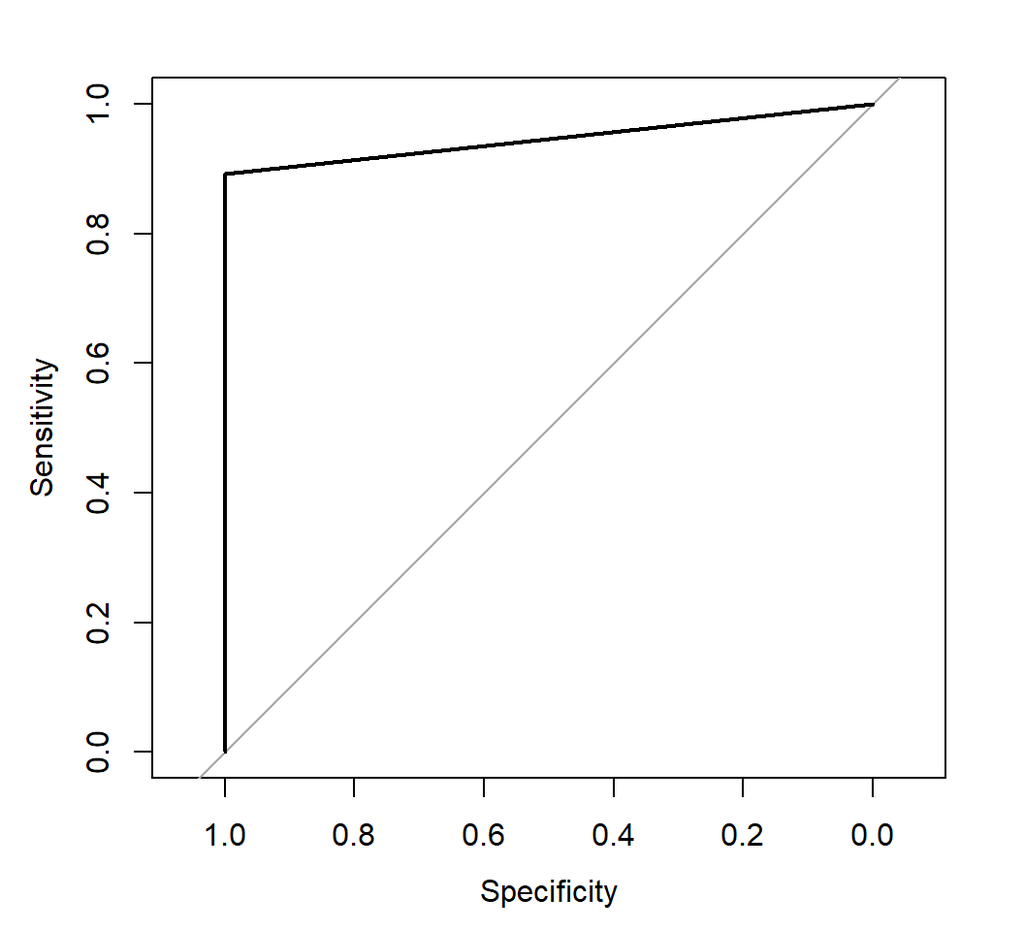

```r
plot(log.roc,ylim=c(0,1))
```

```r
auc.log <-log.roc$auc
```

## LDA

```r
library(MASS)
#train model
lda.spec <- trainControl(method="cv", number = 10, savePredictions = TRUE)

lda.mod <- train(Class~., data = train, method = "lda", trControl = lda.spec)
lda.mod
```

```
#> Linear Discriminant Analysis
#>
#> 44272 samples
#>     3 predictor
#>     5 classes: 'Blue.Tarp', 'Rooftop', 'Soil', 'Various.Non.Tarp', 'Vegetation'
#>
#> No pre-processing
#> Resampling: Cross-Validated (10 fold)
#> Summary of sample sizes: 39846, 39846, 39843, 39847, 39845, 39844, ...
#> Resampling results:
#>
#>   Accuracy   Kappa
#>   0.8558236  0.7881115
```

```r
#preparing data for confusion matrix
lda.pred<-predict(lda.mod, newdata=test)

#confusion matrix
c.matrixlda<- confusionMatrix(data=lda.pred, reference=test$Class)
c.matrixlda
```

```
#> Confusion Matrix and Statistics
#>
#>                   Reference
#> Prediction         Blue.Tarp Rooftop Soil Various.Non.Tarp Vegetation
#>   Blue.Tarp              502       1    1                1          0
#>   Rooftop                 40    1994  318              351          0
#>   Soil                     0     328 5708              425          0
#>   Various.Non.Tarp         0     592   97              234          2
#>   Vegetation              64      55   45              412       7799
#>
#> Overall Statistics
#>
#>                Accuracy : 0.856
#>                  95% CI : (0.8509, 0.8609)
#>     No Information Rate : 0.4112
#>     P-Value [Acc > NIR] : < 2.2e-16
#>
#>                   Kappa : 0.7885
#>
#>  Mcnemar's Test P-Value : < 2.2e-16
#>
#> Statistics by Class:
#>
#>                      Class: Blue.Tarp Class: Rooftop Class: Soil
#> Sensitivity                   0.82838         0.6714      0.9253
#> Specificity                   0.99984         0.9557      0.9412
#> Pos Pred Value                0.99406         0.7377      0.8835
#> Neg Pred Value                0.99437         0.9400      0.9631
#> Prevalence                    0.03195         0.1566      0.3252
#> Detection Rate                0.02646         0.1051      0.3009
#> Detection Prevalence          0.02662         0.1425      0.3406
#> Balanced Accuracy             0.91411         0.8135      0.9332
#>                      Class: Various.Non.Tarp Class: Vegetation
#> Sensitivity                          0.16444            0.9997
#> Specificity                          0.96062            0.9484
#> Pos Pred Value                       0.25297            0.9312
#> Neg Pred Value                       0.93411            0.9998
#> Prevalence                           0.07502            0.4112
#> Detection Rate                       0.01234            0.4111
#> Detection Prevalence                 0.04876            0.4415
#> Balanced Accuracy                    0.56253            0.9741
```

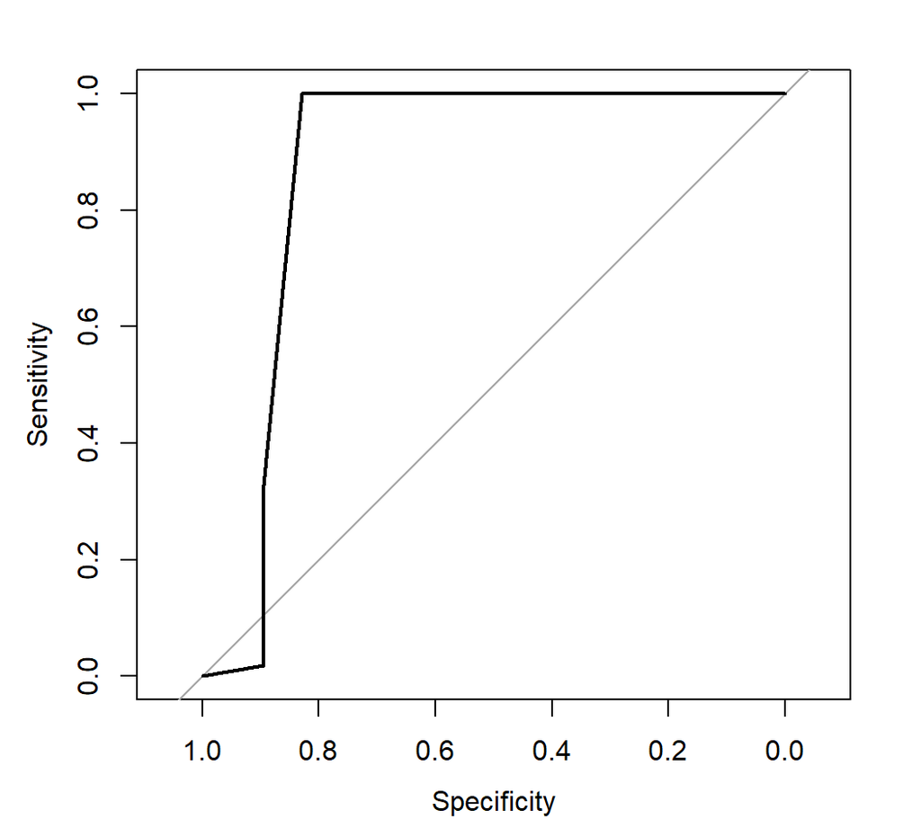

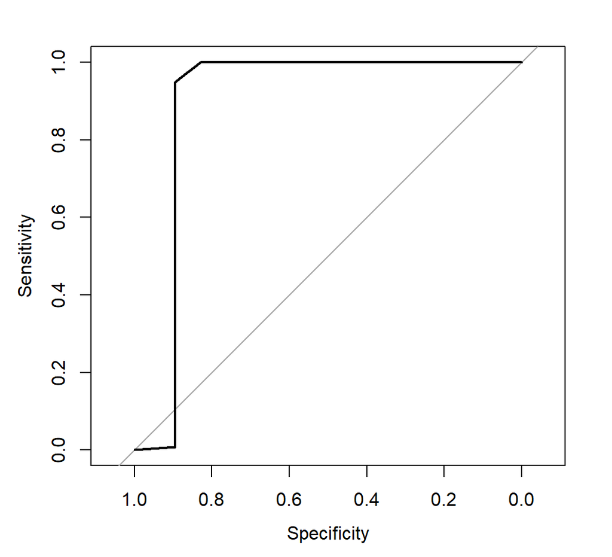

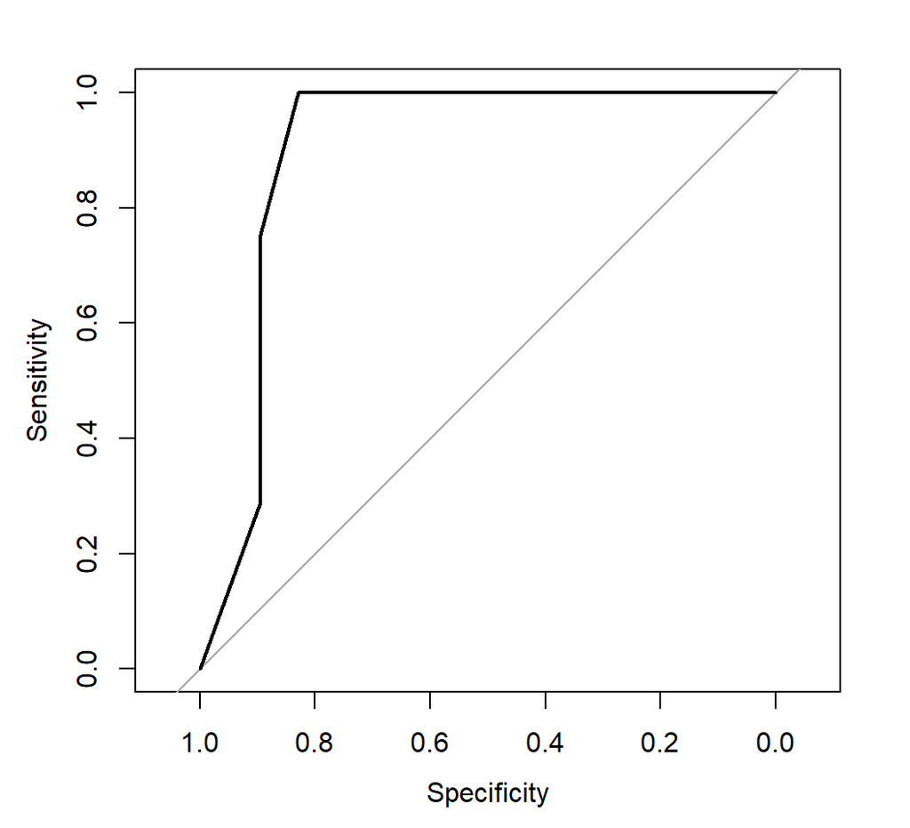

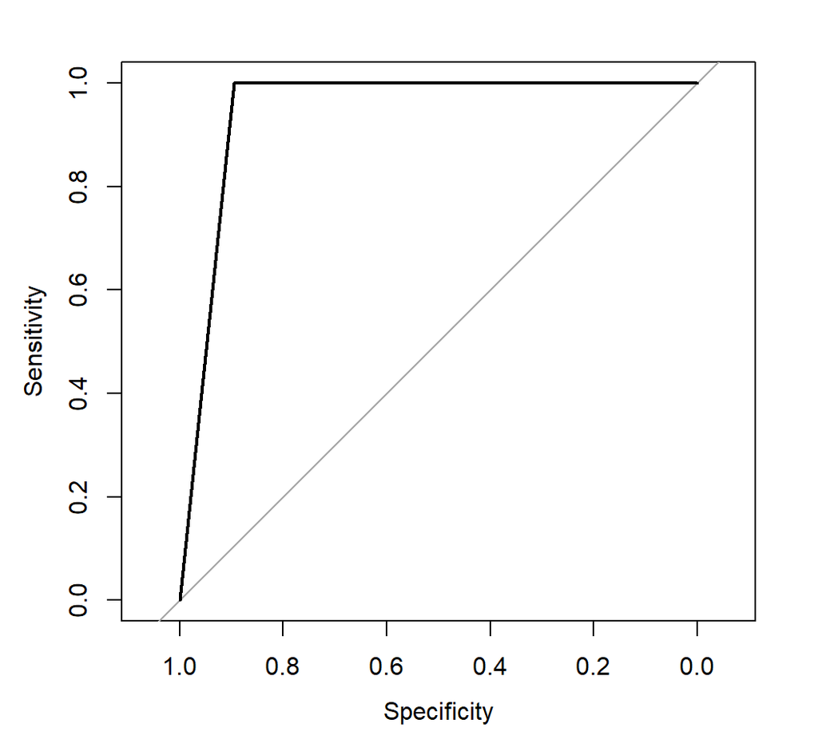

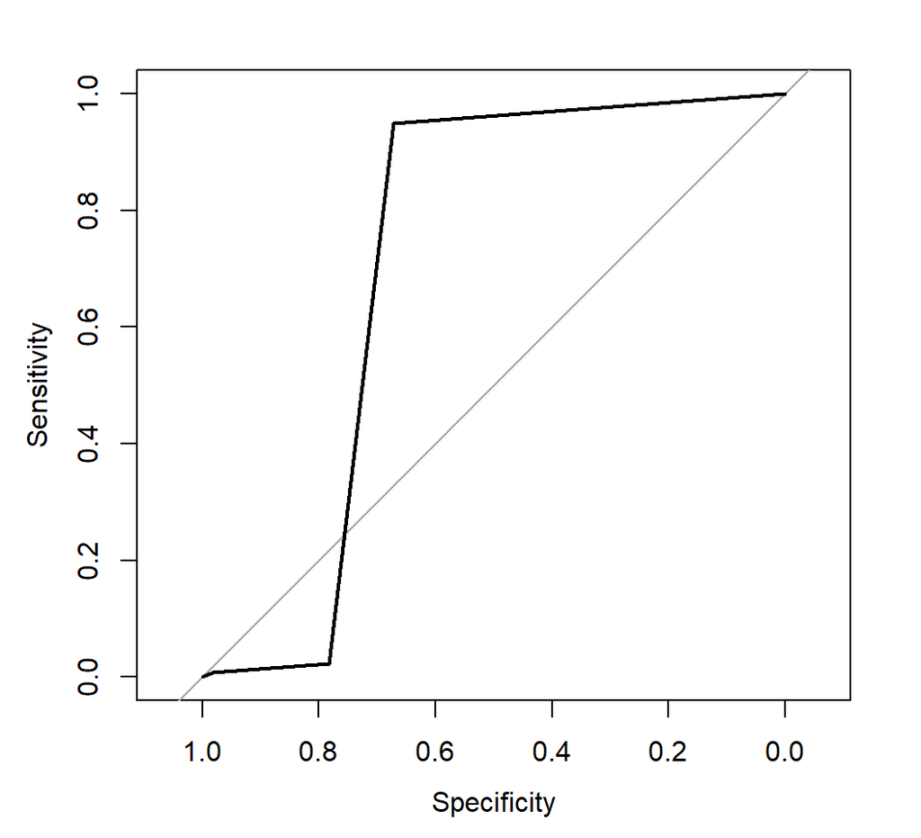

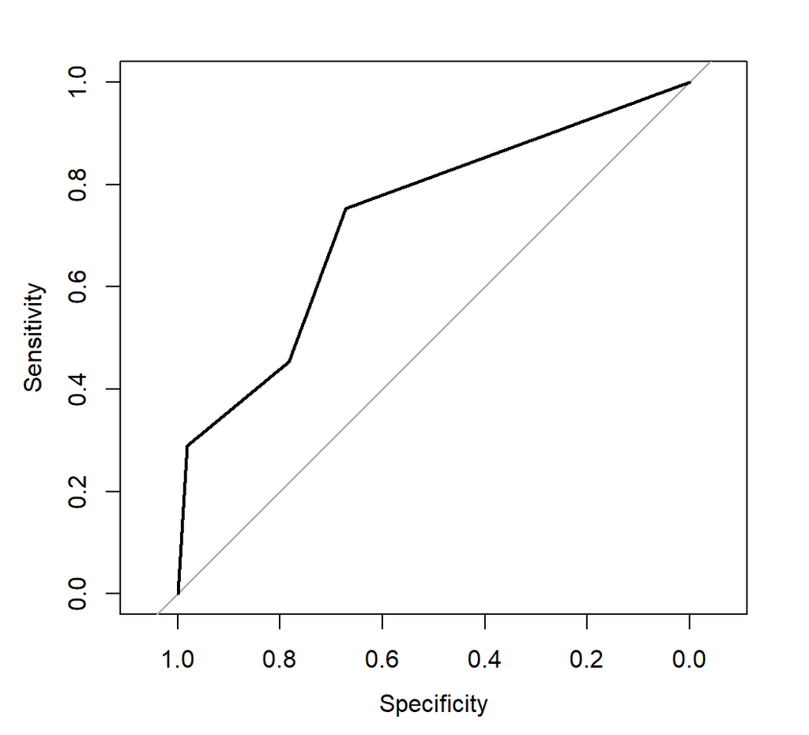

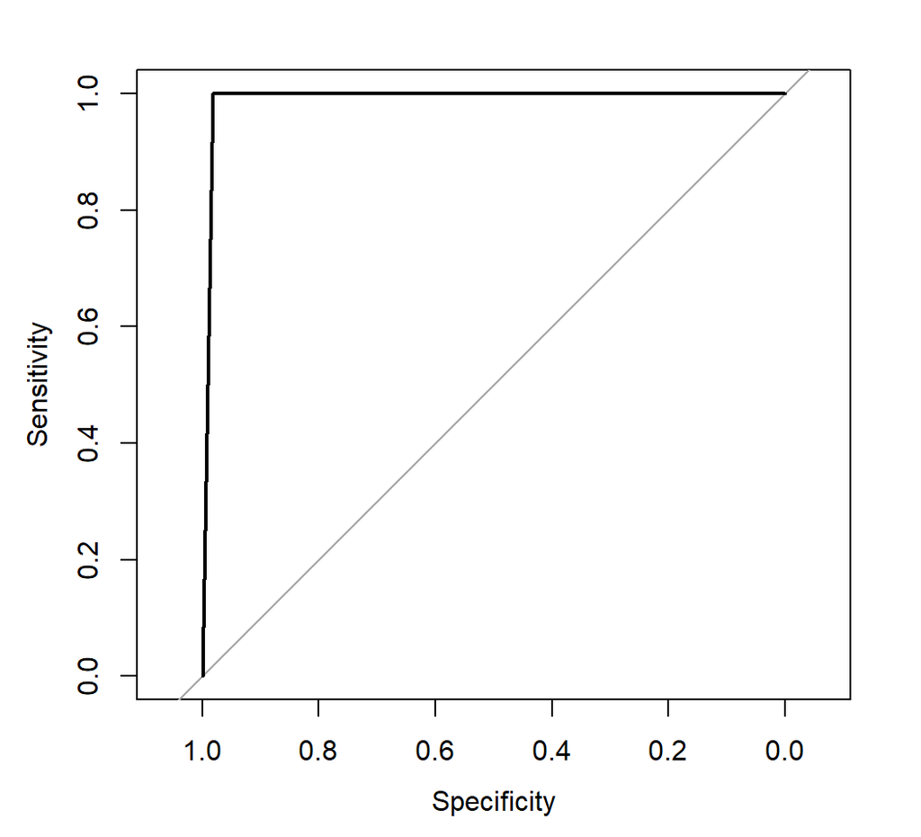

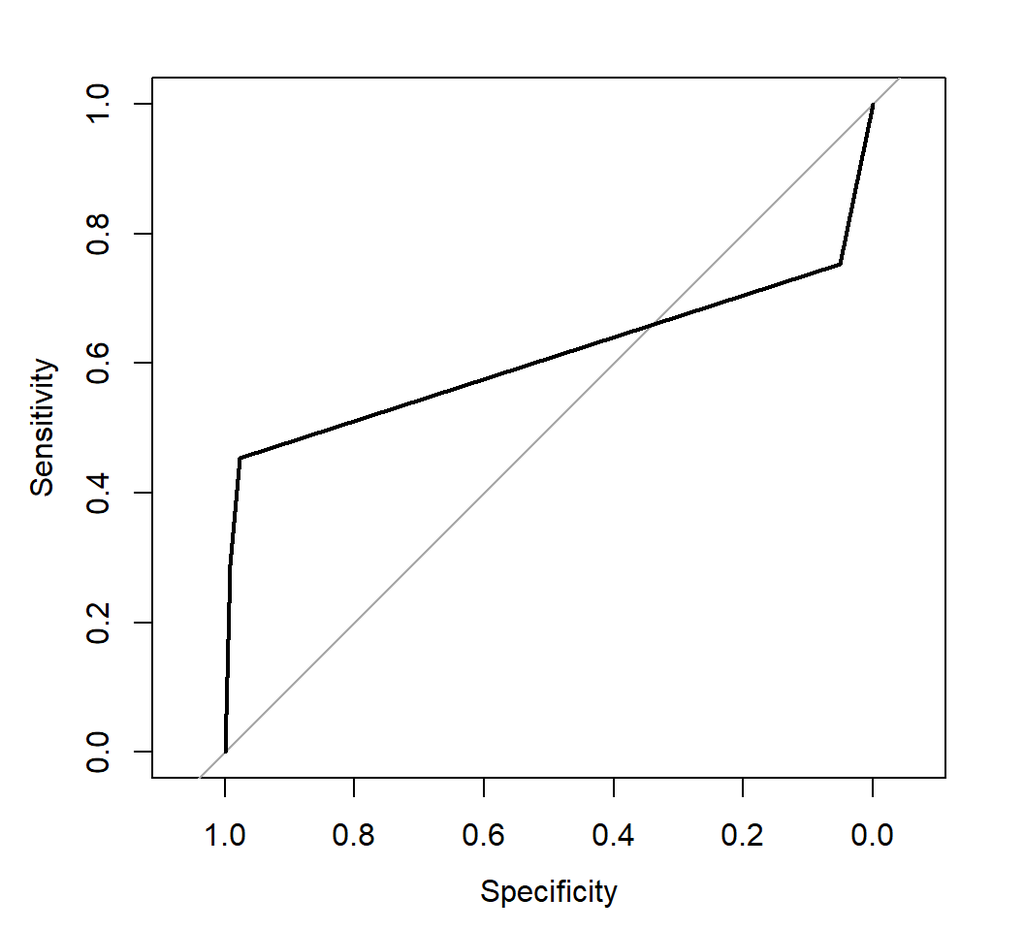

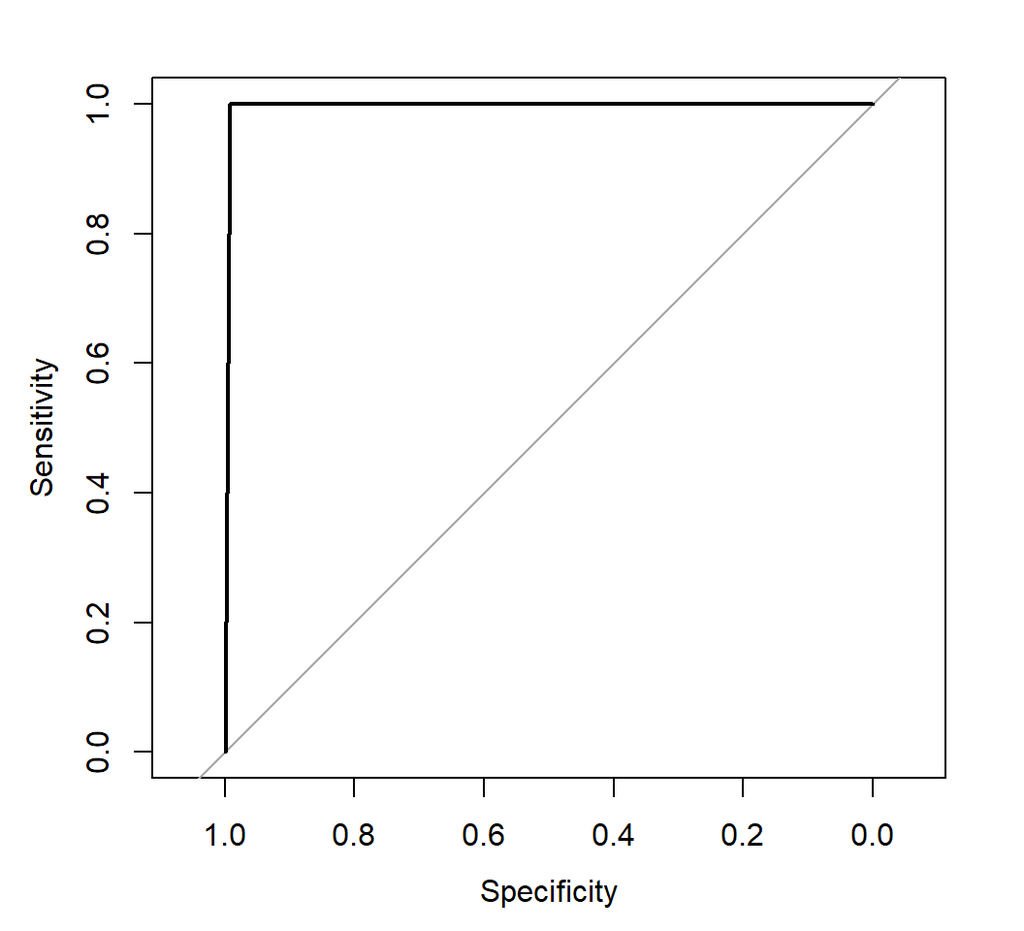

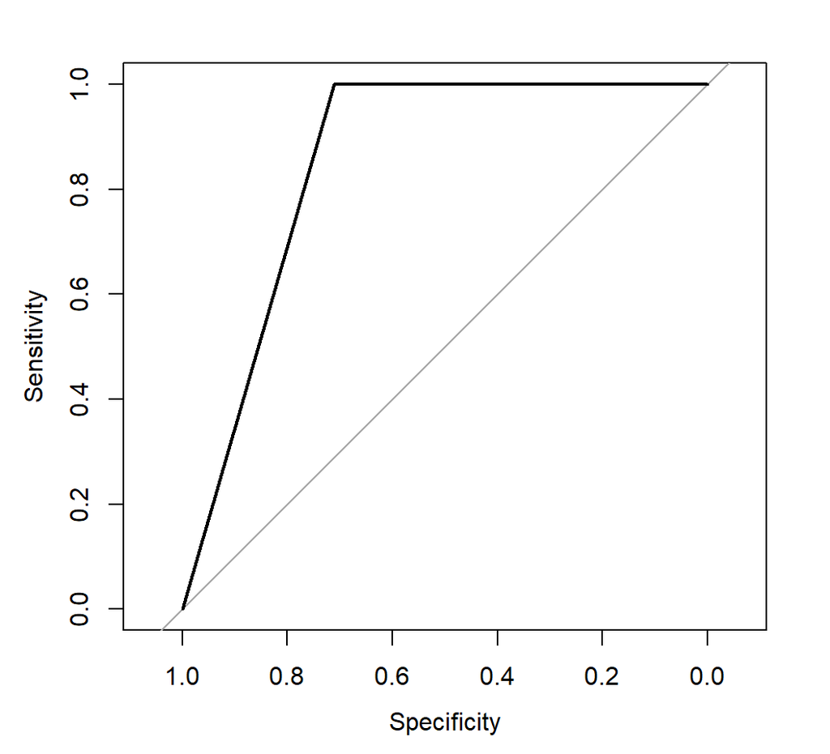

```r
#ROC/AUC
library(pROC)
library(randomForest)
pred.lda <-predict(lda.mod, test, probability = TRUE)
pred.lda<- as.ordered(pred.lda)

roc.lda <-multiclass.roc(predictor = pred.lda, response = test$Class, plot=TRUE)
```

```r
auc.lda <- roc.lda$auc

#calculating values for CV table
tp.lda <- (c.matrixlda$table[1,1]) #true positive
fp.lda <-(sum(sum(c.matrixlda$table[1,2:5]),(sum(c.matrixlda$table[2,3:5])),sum(c.matrixlda$table[3,4:5]),sum(c.matrixlda$table[4,5]))) # false positive
fn.lda <- sum(sum(c.matrixlda$table[2,1]),(sum(c.matrixlda$table[3,1:2])),(sum(c.matrixlda$table[4,1:3])),(sum(c.matrixlda$table[5,1:4]))) #false negative
tn.lda <-sum(c.matrixlda$table[2,2],c.matrixlda$table[3,3], c.matrixlda$table[4,4], c.matrixlda$table[5,5]) # true negative
cp.lda<- tp.lda + fn.lda #condition positive (true positive + false negative)
cn.lda <- fp.lda + tn.lda #condition negative (false positive + true negative)
total.lda <- tp.lda+fp.lda+fn.lda+tn.lda

precision.lda <- tp.lda/(tp.lda+fp.lda)

tpr.lda <- (tp.lda/cp.lda) #true positive rate/sensitivity
fpr.lda <- (fp.lda/cn.lda) #false positive rate
accuracy.lda <- c.matrixlda$overall["Accuracy"]
```

## QDA

```r
qda.spec <- trainControl(method="cv", number = 10)

qda.mod <- train(Class~., data = train, method = "qda", trControl = lda.spec)

qda.mod
```

```
#> Quadratic Discriminant Analysis
#>
#> 44272 samples
#>     3 predictor
#>     5 classes: 'Blue.Tarp', 'Rooftop', 'Soil', 'Various.Non.Tarp', 'Vegetation'
#>
#> No pre-processing
#> Resampling: Cross-Validated (10 fold)
#> Summary of sample sizes: 39845, 39845, 39845, 39845, 39844, 39844, ...
#> Resampling results:
#>
#>   Accuracy   Kappa
#>   0.9011563  0.8558362
```

```r
#predict on model
qda.pred<-predict(qda.mod, newdata=test)

#confusion matrix
c.matrixqda<- confusionMatrix(data=qda.pred, reference=test$Class)
c.matrixqda
```

```
#> Confusion Matrix and Statistics
#>
#>                   Reference
#> Prediction         Blue.Tarp Rooftop Soil Various.Non.Tarp Vegetation
#>   Blue.Tarp              529      13    3                1          0
#>   Rooftop                 22    2674  211              324          7
#>   Soil                     0     197 5747              404          0
#>   Various.Non.Tarp        55      86  208              387         52
#>   Vegetation               0       0    0              307       7742
#>
#> Overall Statistics
#>
#>                Accuracy : 0.9004
#>                  95% CI : (0.896, 0.9046)
#>     No Information Rate : 0.4112
#>     P-Value [Acc > NIR] : < 2.2e-16
#>
#>                   Kappa : 0.8547
#>
#>  Mcnemar's Test P-Value : NA
#>
#> Statistics by Class:
#>
#>                      Class: Blue.Tarp Class: Rooftop Class: Soil
#> Sensitivity                   0.87294         0.9003      0.9316
#> Specificity                   0.99907         0.9647      0.9530
#> Pos Pred Value                0.96886         0.8258      0.9053
#> Neg Pred Value                0.99582         0.9812      0.9666
#> Prevalence                    0.03195         0.1566      0.3252
#> Detection Rate                0.02789         0.1410      0.3030
#> Detection Prevalence          0.02878         0.1707      0.3347
#> Balanced Accuracy             0.93601         0.9325      0.9423
#>                      Class: Various.Non.Tarp Class: Vegetation
#> Sensitivity                          0.27196            0.9924
#> Specificity                          0.97715            0.9725
#> Pos Pred Value                       0.49112            0.9619
#> Neg Pred Value                       0.94302            0.9946
#> Prevalence                           0.07502            0.4112
#> Detection Rate                       0.02040            0.4081
#> Detection Prevalence                 0.04154            0.4243
#> Balanced Accuracy                    0.62455            0.9825
```

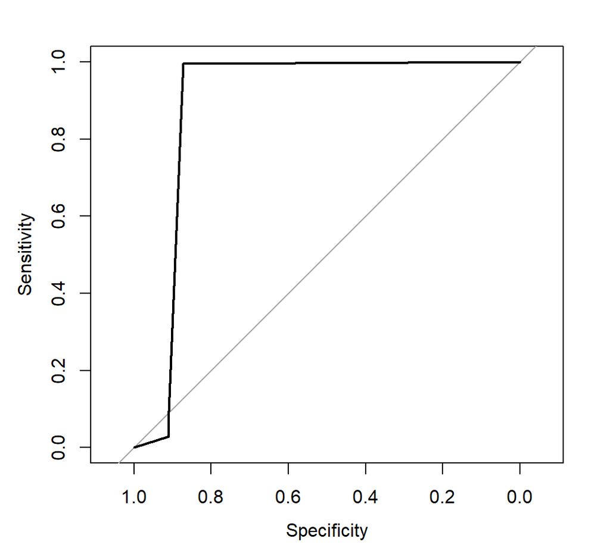

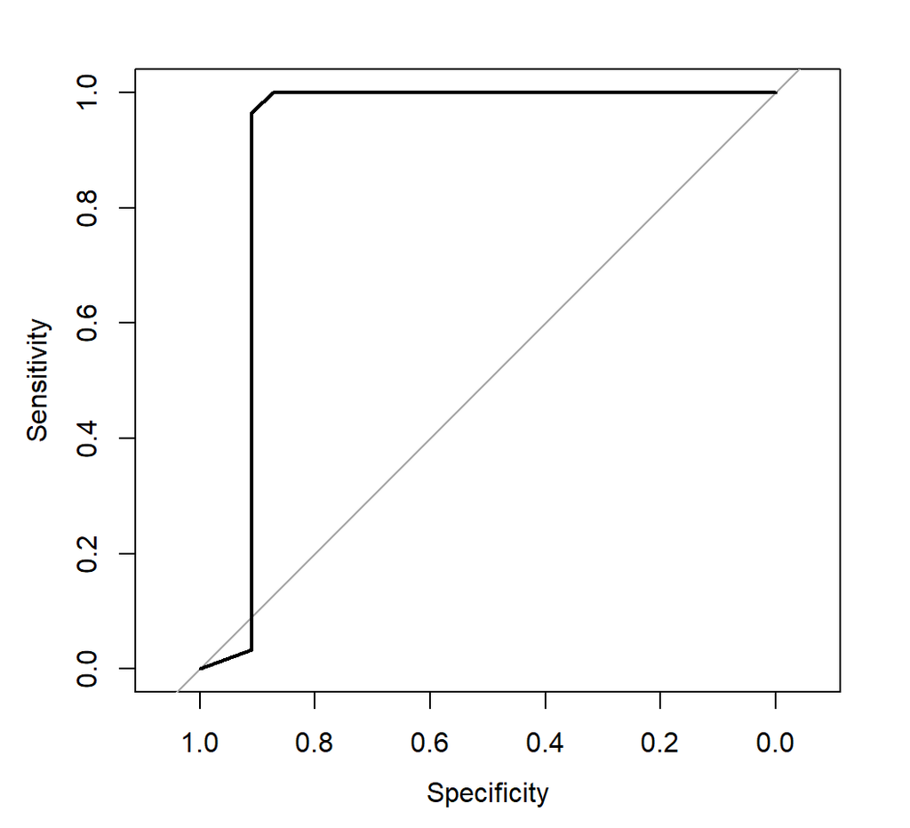

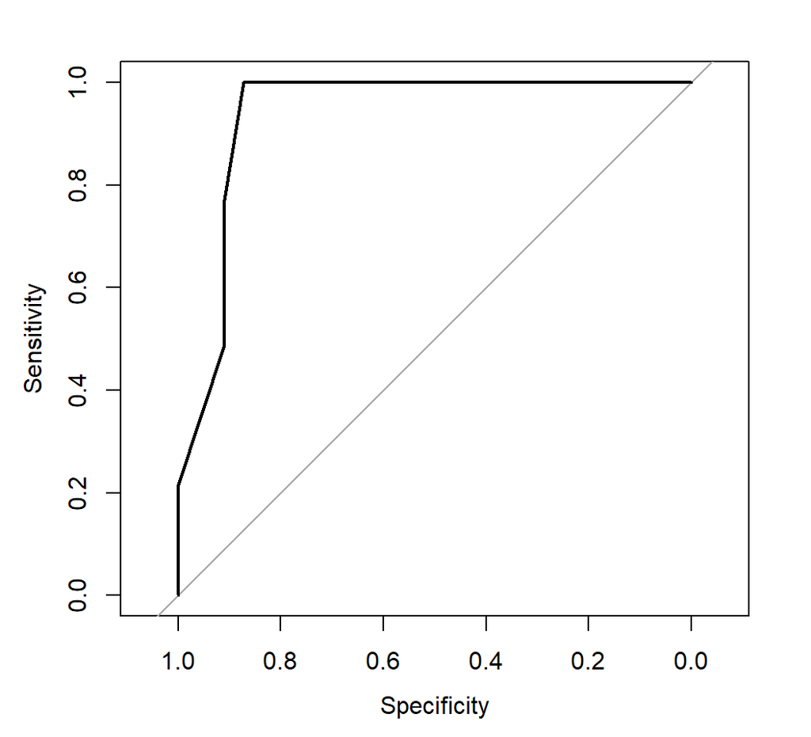

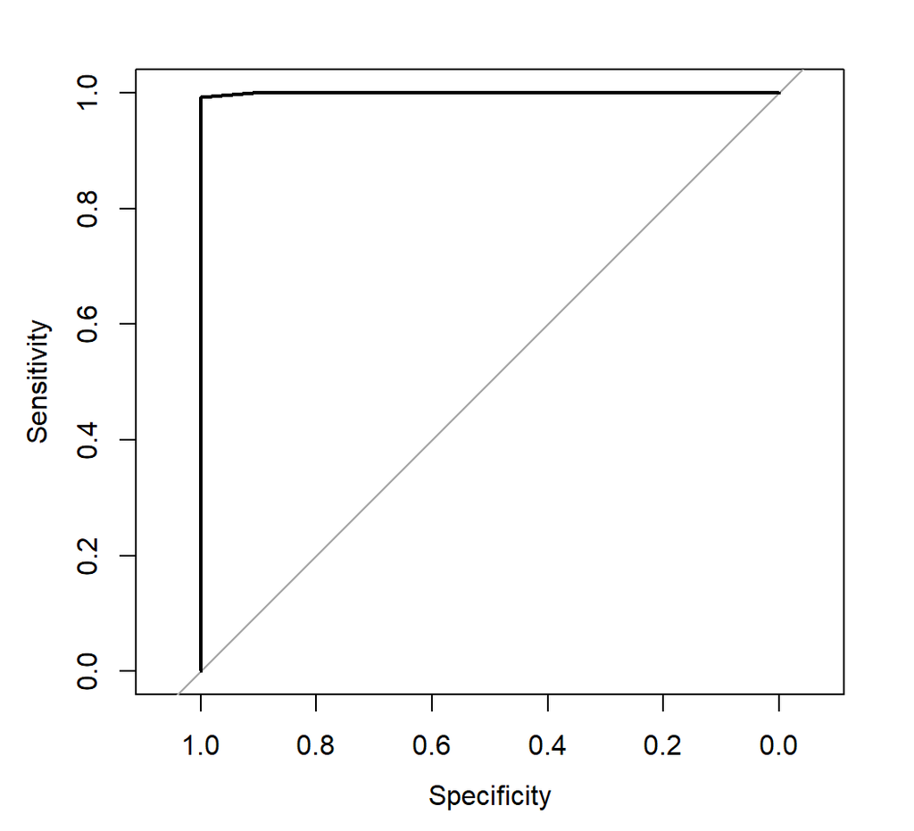

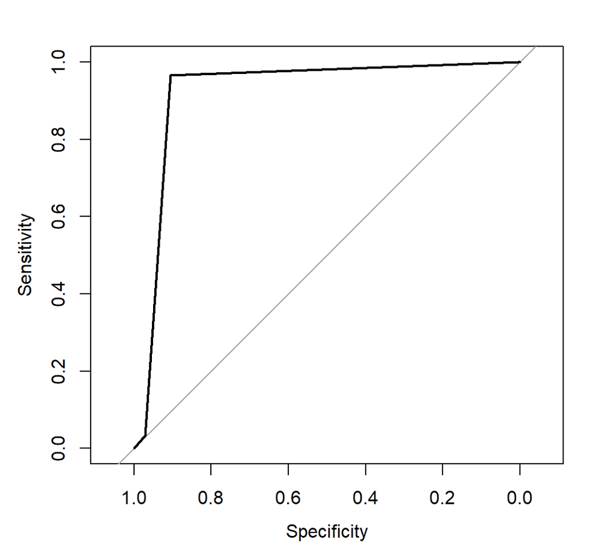

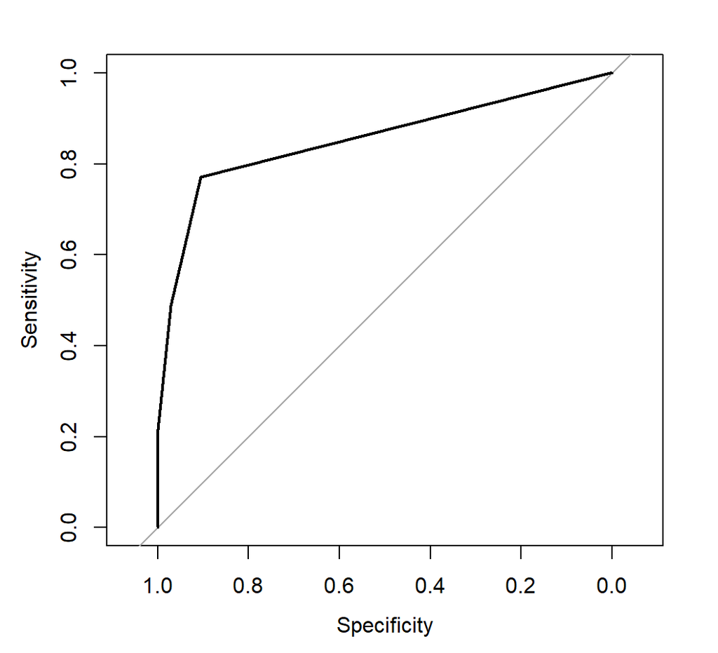

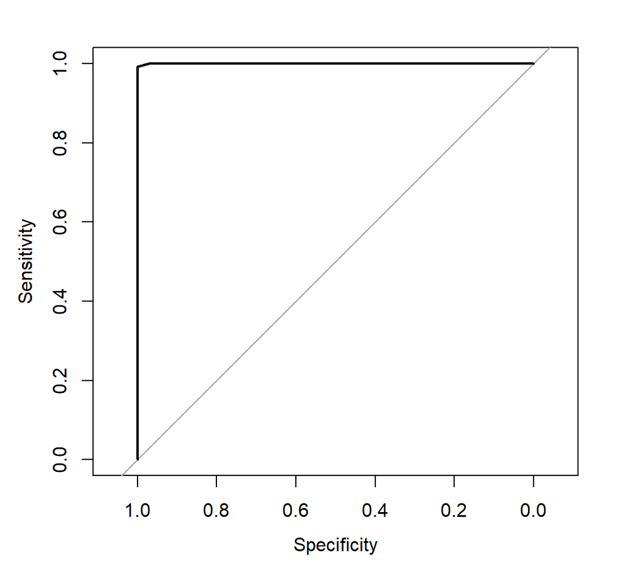

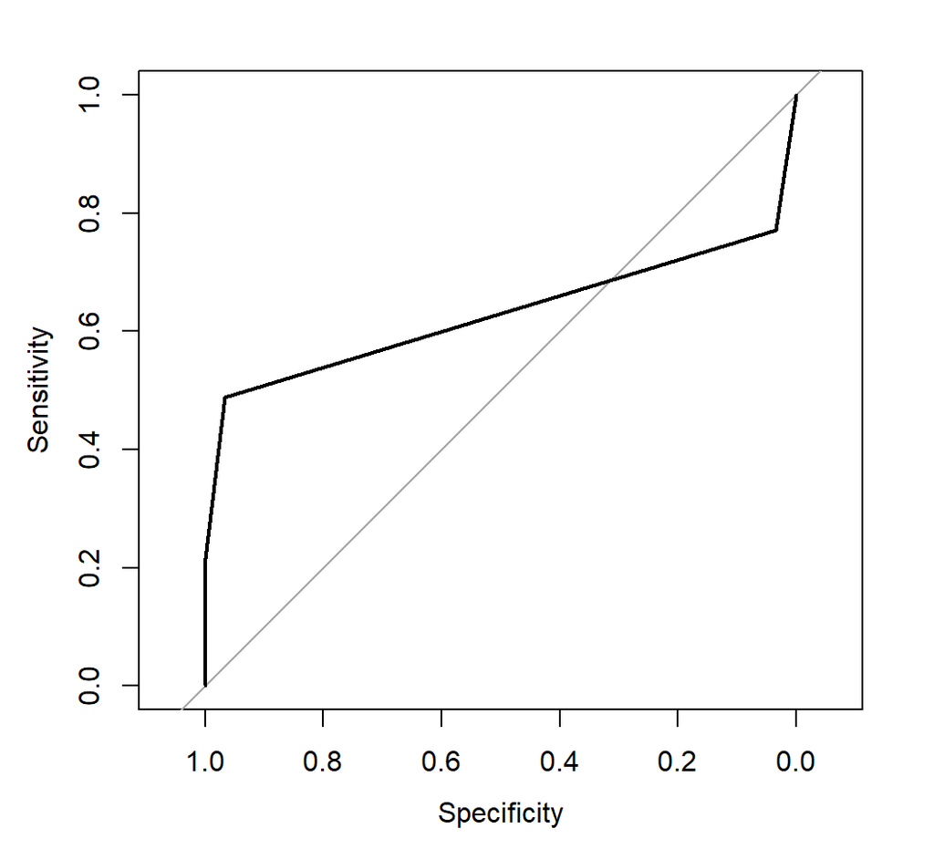

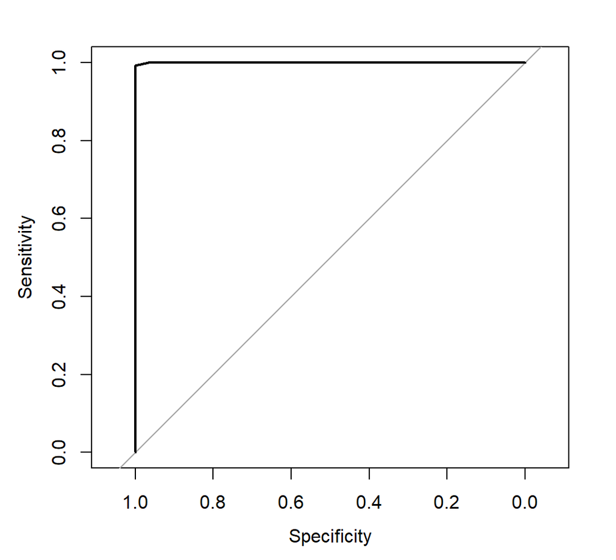

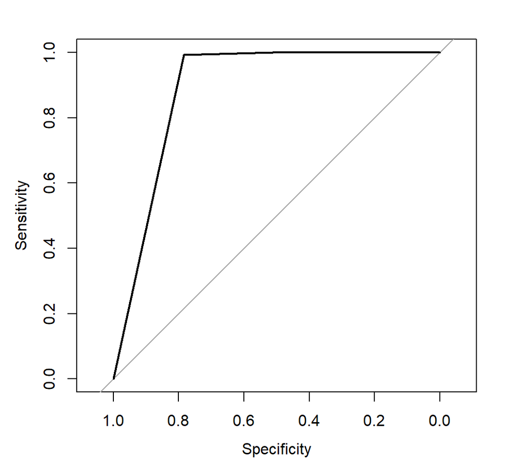

```r
#ROC/AUC
pred.qda <-predict(qda.mod, test, probability = TRUE)
pred.qda <- as.ordered(pred.qda)

roc.qda <-multiclass.roc(predictor = pred.qda, response = test$Class, plot=TRUE)
```

```r
auc.qda <- roc.qda$auc

#calculating values for CV table
#confusion matrix
tp.qda <- (c.matrixqda$table[1,1]) #true positive
fp.qda <-(sum(sum(c.matrixqda$table[1,2:5]),(sum(c.matrixqda$table[2,3:5])),sum(c.matrixqda$table[3,4:5]),sum(c.matrixqda$table[4,5]))) # false positive
fn.qda <- sum(sum(c.matrixqda$table[2,1]),(sum(c.matrixqda$table[3,1:2])),(sum(c.matrixqda$table[4,1:3])),(sum(c.matrixqda$table[5,1:4]))) #false negative
tn.qda <-sum(c.matrixqda$table[2,2],c.matrixqda$table[3,3], c.matrixqda$table[4,4], c.matrixqda$table[5,5]) # true negative
cp.qda<- tp.qda + fn.qda #condition positive
cn.qda <- fp.qda + tn.qda #condition negative
total.qda <- tp.qda+fp.qda+fn.qda+tn.qda

precision.qda <- tp.qda/(tp.qda+fp.qda)

tpr.qda <- tp.qda/cp.qda #true positive rate/sensitivity
fpr.qda <- fp.qda/cn.qda #false positive rate
accuracy.qda <- c.matrixqda$overall["Accuracy"]
```

## K-Nearest Neighbors

```r
library(class)
#http://topepo.github.io/caret/index.html
set.seed(145)
specs <- trainControl(method = "cv", number = 10)

#model
knn.mod <- train(train[,1:3],train[,4],method="knn", trControl=specs, metric = "Accuracy")
knn.mod
```

```
#> k-Nearest Neighbors
#>
#> 44272 samples
#>     3 predictor
#>     5 classes: 'Blue.Tarp', 'Rooftop', 'Soil', 'Various.Non.Tarp', 'Vegetation'
#>
#> No pre-processing
#> Resampling: Cross-Validated (10 fold)
#> Summary of sample sizes: 39845, 39847, 39845, 39845, 39845, 39846, ...
#> Resampling results across tuning parameters:
#>
#>   k  Accuracy   Kappa
#>   5  0.9263189  0.8929492
#>   7  0.9270418  0.8939708
#>   9  0.9276967  0.8949166
#>
#> Accuracy was used to select the optimal model using the largest value.
#> The final value used for the model was k = 9.
```

```r
knn.pred<-predict(knn.mod, test)
#confusion matrix
c.matrixknn <- confusionMatrix(data=knn.pred, reference = test$Class)
c.matrixknn
```

```
#> Confusion Matrix and Statistics
#>
#>                   Reference
#> Prediction         Blue.Tarp Rooftop Soil Various.Non.Tarp Vegetation
#>   Blue.Tarp              582      25    7                2          0
#>   Rooftop                 16    2817  140              137          0
#>   Soil                     0     106 5804              462          0
#>   Various.Non.Tarp         8      22  218              637         78
#>   Vegetation               0       0    0              185       7723
#>
#> Overall Statistics
#>
#>                Accuracy : 0.9259
#>                  95% CI : (0.9221, 0.9296)
#>     No Information Rate : 0.4112
#>     P-Value [Acc > NIR] : < 2.2e-16
#>
#>                   Kappa : 0.8924
#>
#>  Mcnemar's Test P-Value : NA
#>
#> Statistics by Class:
#>
#>                      Class: Blue.Tarp Class: Rooftop Class: Soil
#> Sensitivity                   0.96040         0.9485      0.9408
#> Specificity                   0.99815         0.9817      0.9556
#> Pos Pred Value                0.94481         0.9058      0.9109
#> Neg Pred Value                0.99869         0.9904      0.9710
#> Prevalence                    0.03195         0.1566      0.3252
#> Detection Rate                0.03068         0.1485      0.3060
#> Detection Prevalence          0.03247         0.1640      0.3359
#> Balanced Accuracy             0.97927         0.9651      0.9482
#>                      Class: Various.Non.Tarp Class: Vegetation
#> Sensitivity                          0.44765            0.9900
#> Specificity                          0.98142            0.9834
#> Pos Pred Value                       0.66147            0.9766
#> Neg Pred Value                       0.95635            0.9929
#> Prevalence                           0.07502            0.4112
#> Detection Rate                       0.03358            0.4071
#> Detection Prevalence                 0.05077            0.4169
#> Balanced Accuracy                    0.71453            0.9867
```